# Introduction to Neural Networks

3/17/2021

## Neural Nets

How do we improve upon the forecasting accuracy of a simpler model?

Options:

- use bespoke column transformations (using subject-matter expertise), or
- use a more flexible model, or
- do both!

## Neural Nets

**Neural nets** are a class of nonlinear models that tend to

- be used for larger data sets (i.e. text, speech, images, etc.),
- have many parameters,
- and are biologically inspired.

We will focus on **feedforward networks**, and we’ll use Keras.

[figure not shown]

## Our Example: MNIST

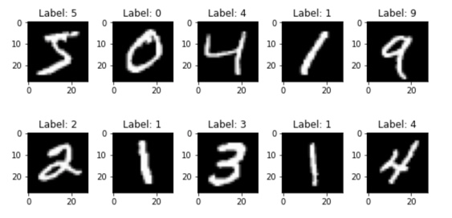

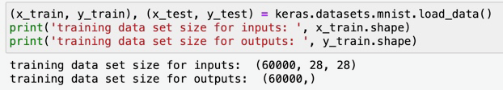

## This Lecture

This is a big field!

Topics I won’t get to:

- other types of neural nets (i.e. RNNs, RBMs, autoencoders, etc.)
- when/if \(\exists\) theoretical guarantees
- other types of data (speech, text, etc.)
- details of optimization algorithms
- regularization
- a detailed overview of this software (or other libraries)
- other types of layers and strategies

Check out the code: https://github.com/tbrown122387/NN-lecture/

## A Starting Point: Softmax Regression

Approximate \(\mathbf{y}\) with \[ f(\mathbf{x}) = \text{softmax}( \mathbf{W}^\intercal\mathbf{x} + \mathbf{b} ) \] where \[ \text{softmax}\left( \begin{bmatrix} z_1 \\ \vdots \\ z_{n} \end{bmatrix} \right) = \begin{bmatrix} \exp(z_1) \\ \vdots \\ \exp(z_n) \end{bmatrix} \Bigg / \left( \sum_{i=1}^{n}\exp(z_i) \right) \]

- \(\mathbf{y} \in \{(0, \ldots, 1), \ldots, (1, \ldots, 0)\}\)
- \(\mathbf{x}\) is a length \(784\) vector (a `Flatten`ed \(28 \times 28 \times 1\) tensor)
- \(\mathbf{b}\) is a vector of bias parameters
- \(\mathbf{W}\) is a tall and skinny matrix of weight parameters

## A Starting Point: Softmax Regression

\[ f(\mathbf{x}) = \text{softmax}( \mathbf{W}^\intercal\mathbf{x} + \mathbf{b} ) \]

## A Starting Point: Softmax Regression

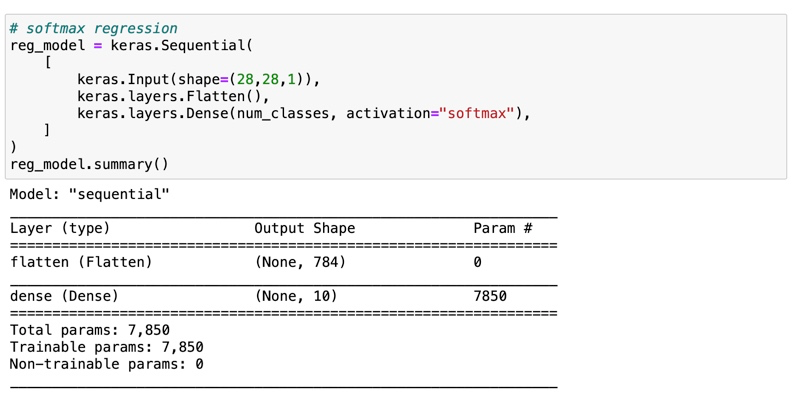

## Training Our Regression Model

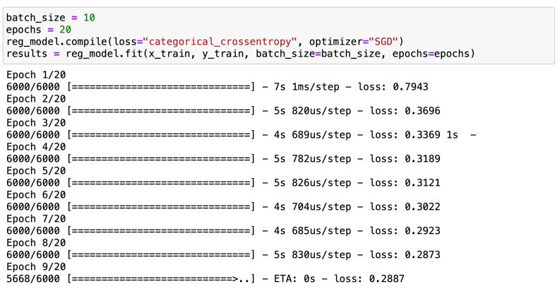

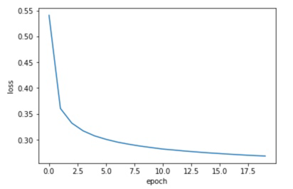

## What \(\mathbf{W}\) is this model learning?

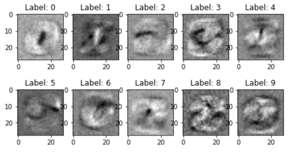

Classification accuracy on the test data: \(92.34\%\).

**We can improve the accuracy if we transform the inputs intelligently. That’s what hidden layers are for.**

## Adding a Hidden Layer

Approximate \(\mathbf{y}\) with \[ f(\mathbf{x}) = \text{softmax}( \mathbf{W}^{(2)\intercal}\mathbf{h} + \mathbf{b}^{(2)} ) \] where \[ \mathbf{h} = g(\mathbf{W}^{(1)\intercal} \mathbf{x} + \mathbf{b}^{(1)}) \] is the hidden layer, and \(g\) is a nonlinear, elementwise, (usually) paramater-free **activation function**.

A size \(64\) hidden layer increased accuracy to \(97.31\%\).

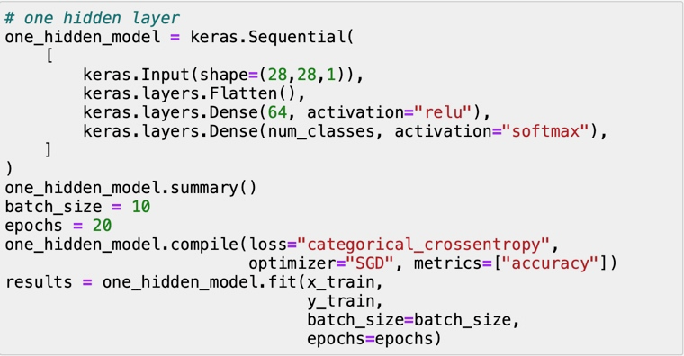

## Visualizing Weights of the Hidden Layer

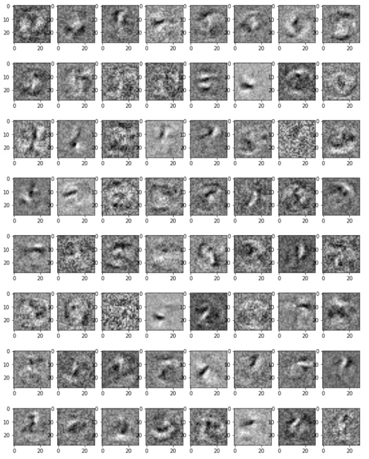

## Visualizing Activations of the Hidden Layer (i.e. \(\mathbf{h}\))

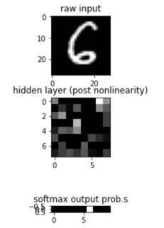

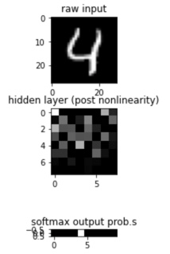

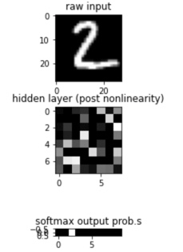

## Convolutional Neural Networks

**Convolutional networks** have at least one layer that uses *convolution* instead of general matrix multiplication. They are popular for analyzing data that possess a grid-like topology.

They feature **sparse interactions**, **parameter sharing** and **equivariant representations**. They are also useful if your input images have different shapes!

## Convolutional Neural Networks

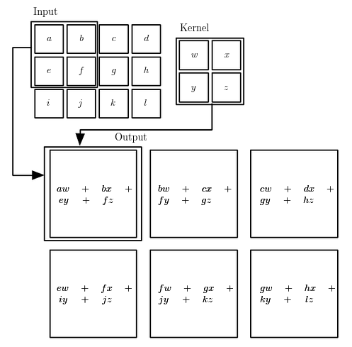

Figure from *Deep Learning* (Goodfellow, Bengio and Courville)

## Max Pooling Layers

**Max pooling** layers are often added after a convolutional layer.

These help make the representation invariant to small shifts in the image, which can be a useful property if we care more about *whether* some feature is present rather than exactly *where* it is.

They are also a *parameter-free* way to reduce the size of later layers, which *reduces computational costs* and *prevents overfitting*.

## Convolutional Neural Networks

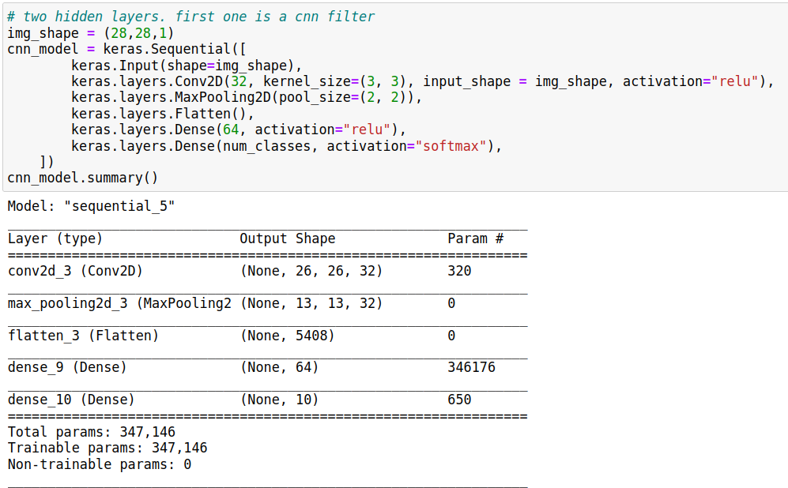

This yields \(98.51\%\) accuracy on the test set.

## Visualizing the Architecture

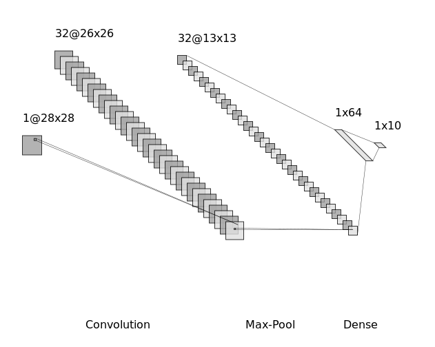

## Visualizing the CNN’s Kernels

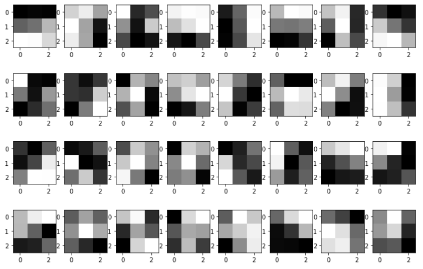

## Visualizing Convolutions

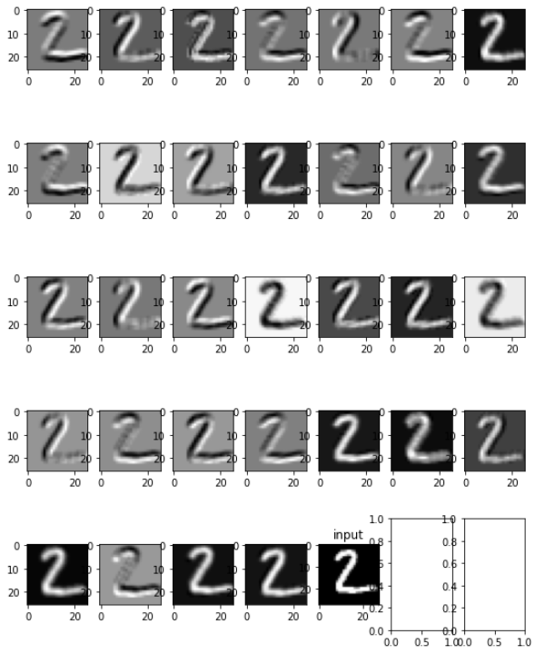

## Thanks!

(and happy St. Patty’s Day!)

[figure not shown]